# Exemple de manipulation de rasters avec `R` et le package `Terra`

## Agréger, ou comment baisser la résolution d’un raster

Les images peuvent être lourdes pour nos machines, pour de nombreuses raisons, il peut être utile de baisser la résolution de l’image. Pour cela, la fonction `aggregate()` va nous aider. Le paramètre `fact = n` renseigne le nombre de pixels que l’on veut en horizontal/vertival. `fun =` permet de préciser la logique par lequel vont être agrégées les valeurs des pixels (mean, max, min, median, sum, etc.)

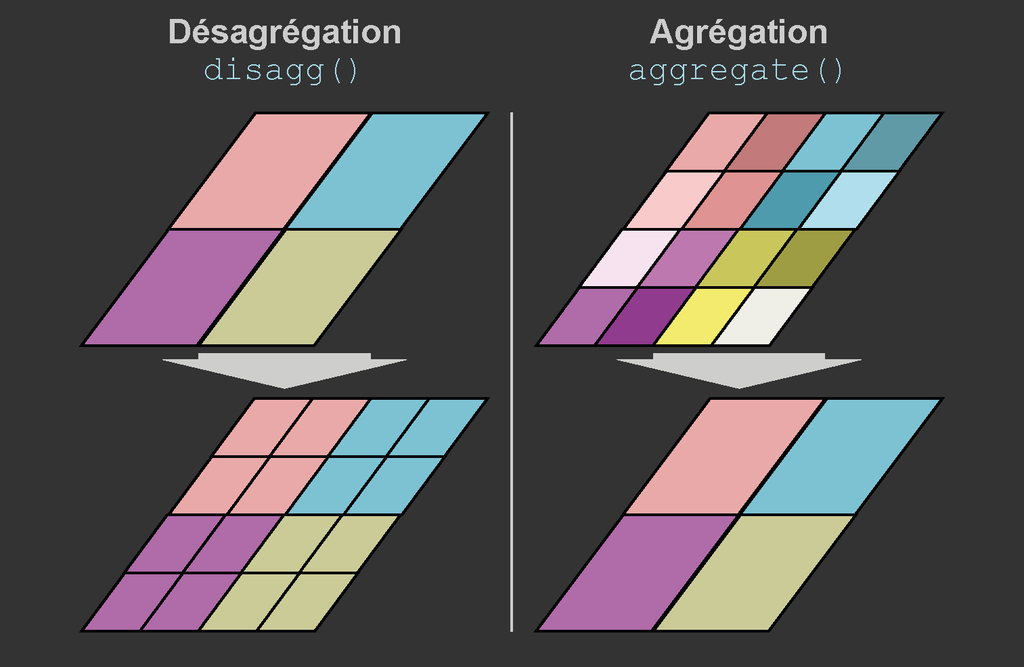

Illustration des fonctions ‘aggregate()’ et ‘disagg()’

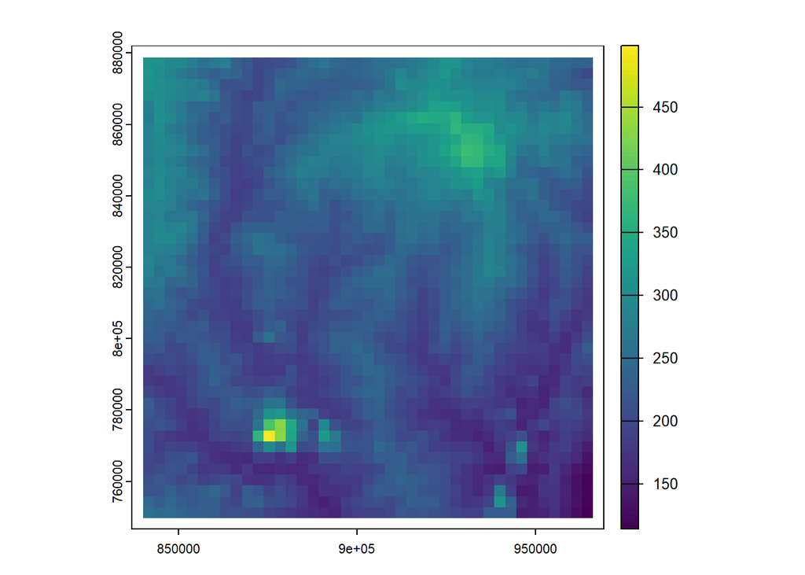

```r
#Changeons la résolution du MNT avec un groupement de 100 pixels par 100 pixels
MNT_allege <- aggregate(MNT, fact = 100, fun = 'mean')
plot(MNT_allege)
```

## Désagréger ou augmenter la résolution d’un raster

Inversement, lorsque des traitements impliquent plusieurs rasters, il peut être nécessaire que les rasters soient à la même résolution. Il est possible d’augmenter la résolution avec la fonction `disagg()`. Comme la fonction `aggregate()`, il faut renseigner le facteur, le nombre de pixels voulus par pixel en horizontal/vertical. `method` renseigne la méthode de désagrégation (*near* = plus proche voisin ou *bilinear*).

```r
#Changeons la résolution pour 2 pixels par 2 pixels pour chaque pixel
MNT_enrichi <- disagg(MNT, fact = 2, method = 'bilinear')
```

Pour connaître la résolution des pixels, il est possible de regarder les métadonnées ou d’utiliser directement la fonction `res()`. L’unité est celle utilisée dans le système de coordonnées.

```r
#Résolution des MNT
res(MNT)
```

```
[1] 30.74511 30.74511
```

```r
res(MNT_allege)
```

```
[1] 3074.511 3074.511
```

```r
#res(MNT_enrichi)
```

**Point déchargement de la ram pour soulager nos ordinateurs**

Les images peuvent être lourdes pour nos ordinateurs. Il est possible de supprimer les objets de la ram avec la fonction `rm()`.

```r
# Nous n'aurons plus besoin de ces objets à l'avenir
rm(MNT_allege, MNT_enrichi)
```